## ──────────

# Upload the file EconomistData.csv from your elearning platform

## These data consist of /Human Development Index/ and /Corruption

## Perception Index/ scores for several countries.

#Transparency International’s (TI) Corruption Perceptions Index1 (CPI) #is an aggregate indicator that #ranks countries in terms of the degree to which corruption #is perceived to exist among public officials and politicians. #It is a composite index drawing on corruption-related data from a variety of reputable #institutions. ## Original sources for these data are ## [http://www.transparency.org/content/download/64476/1031428]

```r
ED<-read.csv("EconomistData.csv")
head(ED)
```

```
##   X     Country HDI.Rank   HDI CPI            Region
## 1 1 Afghanistan      172 0.398 1.5      Asia Pacific
## 2 2     Albania       70 0.739 3.1 East EU Cemt Asia
## 3 3     Algeria       96 0.698 2.9              MENA
## 4 4      Angola      148 0.486 2.0               SSA
## 5 5   Argentina       45 0.797 3.0          Americas
## 6 6     Armenia       86 0.716 2.6 East EU Cemt Asia
```

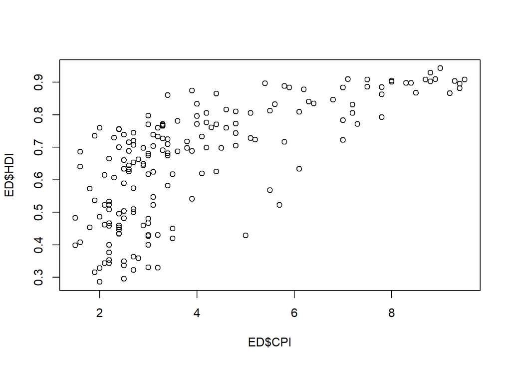

```r
plot(ED$CPI, ED$HDI)
```

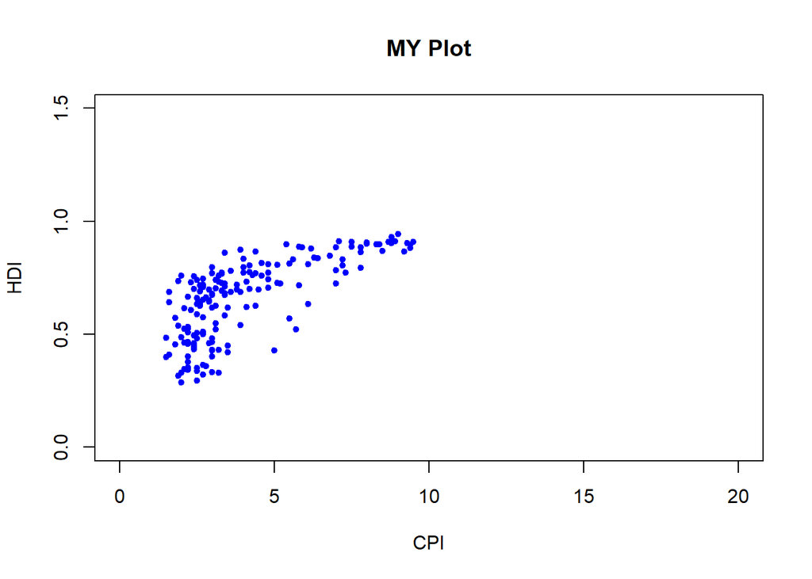

```r
plot(ED$CPI, ED$HDI,xlab = "CPI",ylab="HDI", main="MY Plot",xlim=c(0,20),ylim = c(0,1.5),col='blue',pch=20)
```

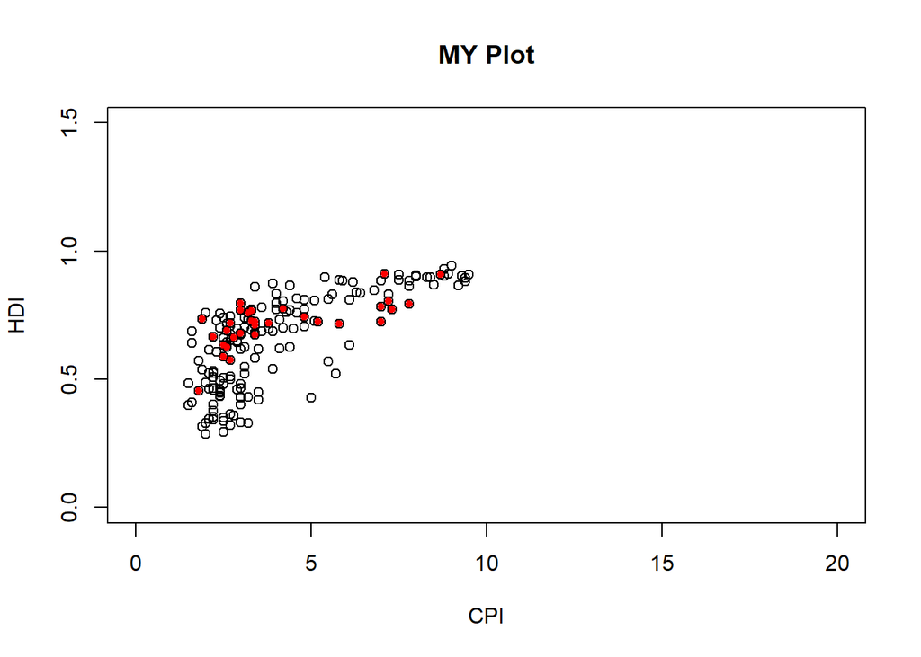

```r
plot(ED$CPI, ED$HDI,xlab = "CPI",ylab="HDI", main="MY Plot",xlim=c(0,20),ylim = c(0,1.5))

points(ED$CPI[ED$Region=='Americas'],ED$HDI[ED$Region=='Americas'],col='red',pch=20)
```

```r
#2. Color the points in the previous plot blue.

#3. Color the points in the previous plot according to Region.

#4. Make the points bigger by setting size to 2


#5.Map the size of the points to HDI.Rank


#6/7. Create boxplots of CPI by Region and Overlay points on top of the box plots
```

```r
dat <- read.csv("EconomistData.csv")
```

```r
library(ggplot2)
```

## 1. Create a scatter plot with CPI on the x axis and HDI on the y axis.

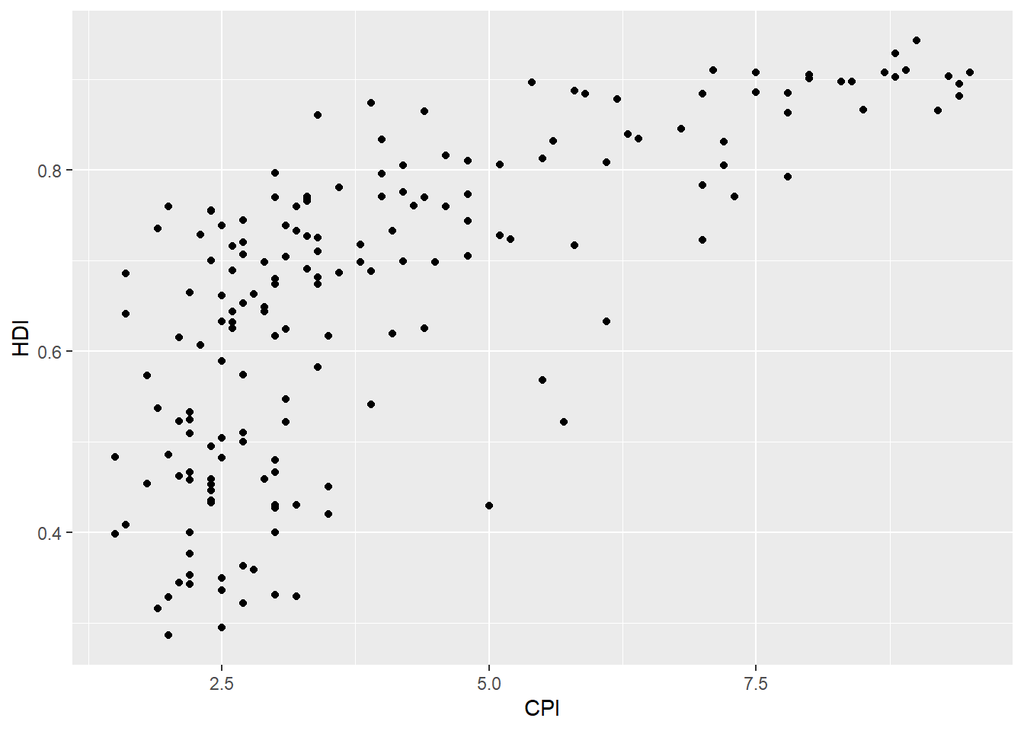

```r
ggplot(dat, aes(x = CPI, y = HDI)) +  geom_point()
```

## 2. Color the points blue.

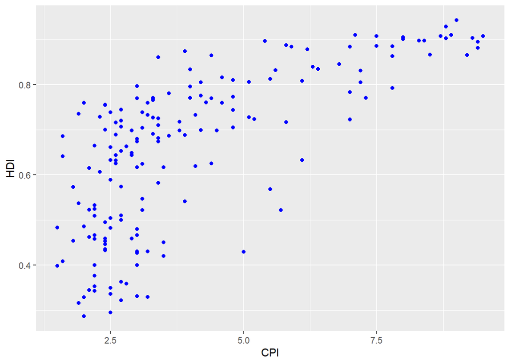

```r
ggplot(dat, aes(x = CPI, y = HDI)) + geom_point(color = "blue")
```

## 3. Map the color of the the points to Region.

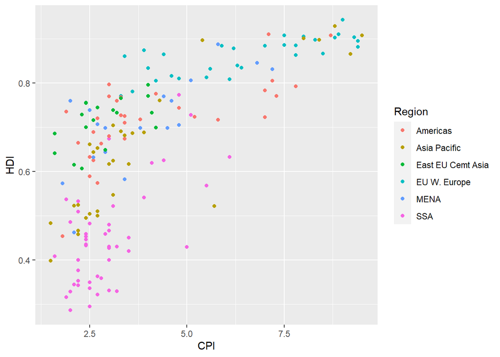

```r
ggplot(dat, aes(x = CPI, y = HDI)) +   geom_point(aes(color = Region))
```

## 4. Make the points bigger by setting size to 2

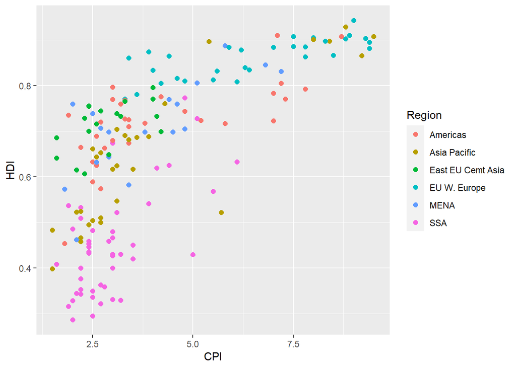

```r
ggplot(dat, aes(x = CPI, y = HDI)) + geom_point(aes(color = Region), size = 2)
```

##5. Map the size of the points to HDI.Rank

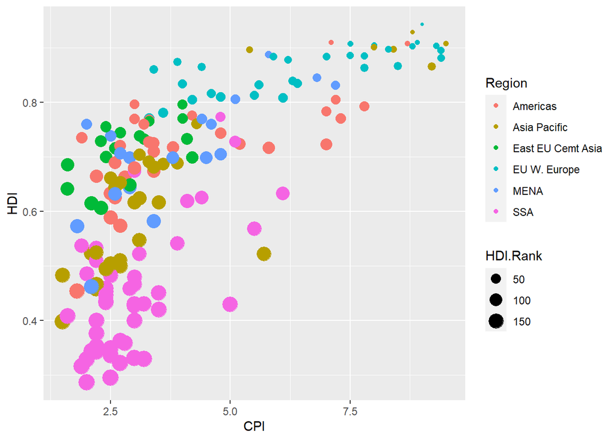

```r
ggplot(dat, aes(x = CPI, y = HDI)) + geom_point(aes(color = Region, size =  HDI.Rank))
```

## Exercise II ## ───────────

## 1. Re-create a scatter plot with CPI on the x axis and HDI on the

## axis (as you did in the previous exercise).

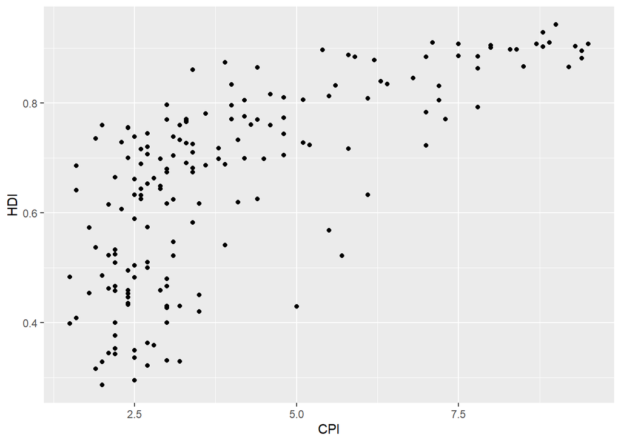

```r
ggplot(dat, aes(x = CPI, y = HDI)) +  geom_point()
```

## 2. Overlay a smoothing line on top of the scatter plot using

## geom_smooth.

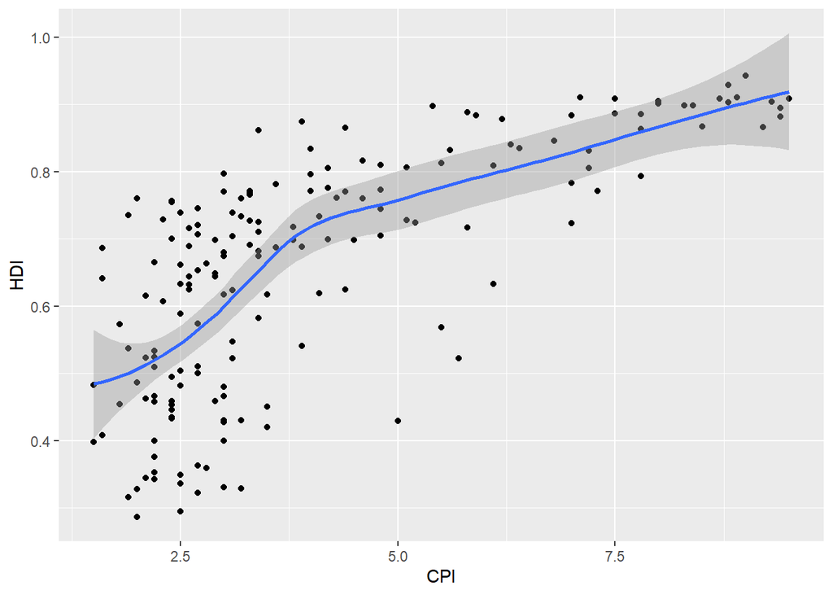

```r
ggplot(dat, aes(x = CPI, y = HDI)) +  geom_point()+geom_smooth()
```

## 3. Overlay a smoothing line on top of the scatter plot using

## geom_smooth, but use a linear model for the predictions. Hint: see

## `?stat_smooth’.

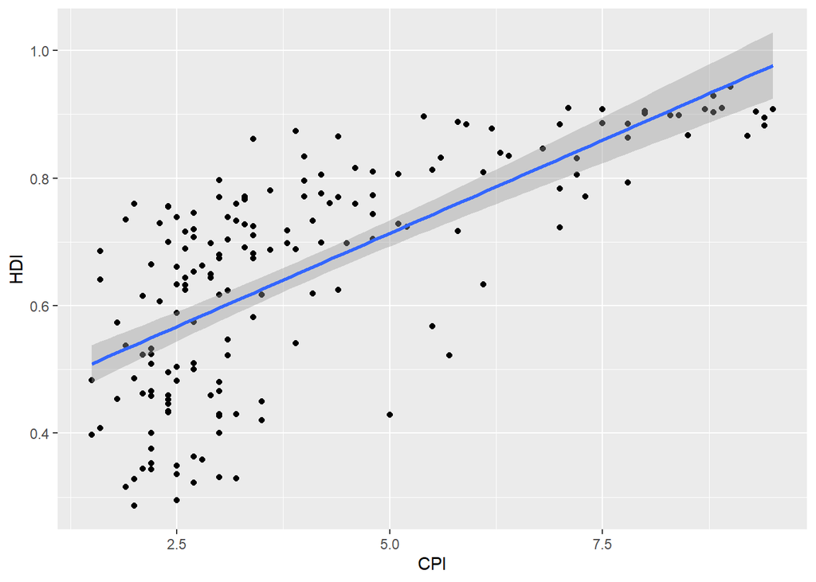

```r
ggplot(dat, aes(x = CPI, y = HDI)) +  geom_point()+geom_smooth(method = "lm")
```

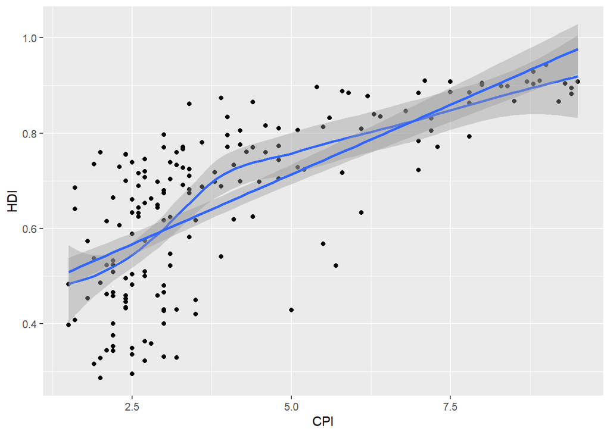

```r
ggplot(dat, aes(x = CPI, y = HDI)) + geom_point()+geom_smooth() + stat_smooth(method = "lm")
```

## 4. Overlay a smoothling line on top of the scatter plot using

## geom_line. Hint: change the statistical transformation.

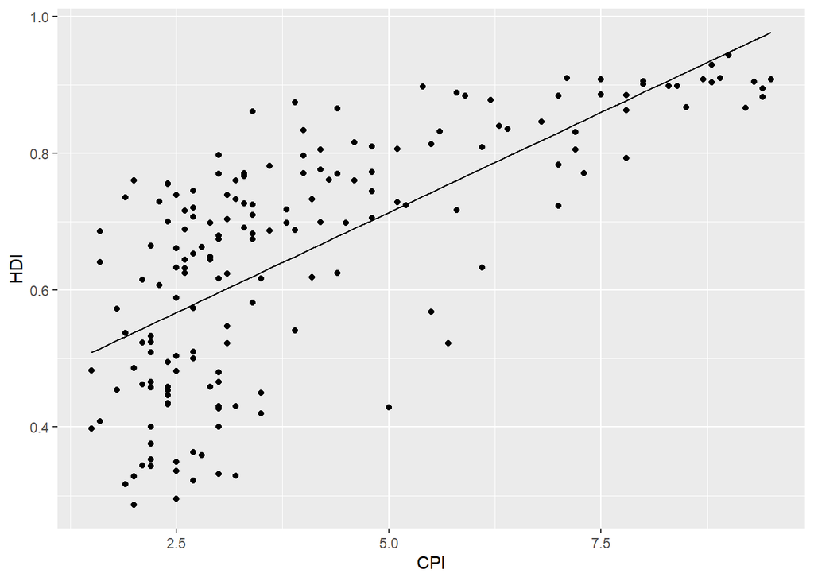

```r
dat$pred.CP <- predict(lm(HDI ~ CPI, data = dat))

p1 <- ggplot(dat, aes(x = CPI, y = HDI))

p1 + geom_point() + geom_line(aes(y = pred.CP))
```

## 5. Overlay a smoothing line on top of the scatter plot using

## the default /loess/ method, but make it less smooth. Hint: see

## `?loess’.

span is used for smooth

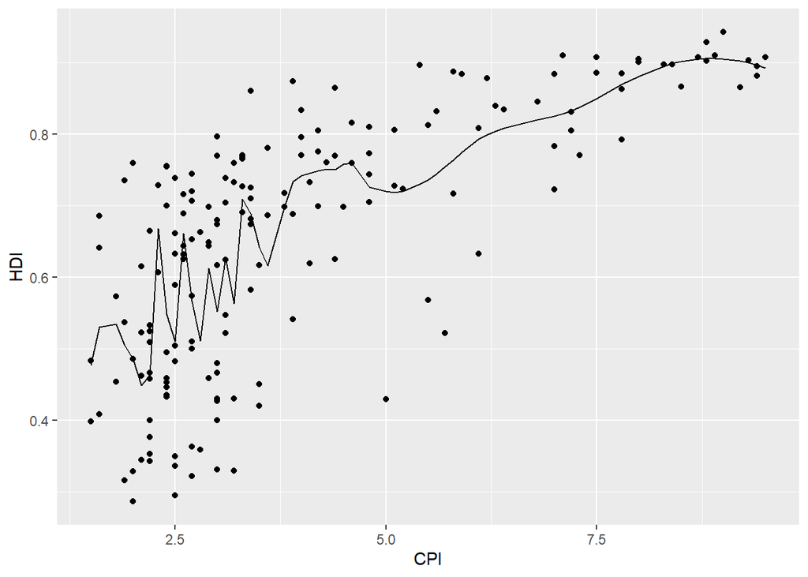

```r
dat$pred.CP <- predict(loess(HDI ~ CPI, data = dat,span = 0.15))

p1 <- ggplot(dat, aes(x = CPI, y = HDI))

p1 + geom_point() + geom_line(aes(y = pred.CP))
```

#smoothing method (function) to use, eg. “lm”, “glm”, “gam”, “loess”, “rlm”. #For method = “auto” the smoothing method is chosen based on the size of the #largest group (across all panels). loess is used for than 1,000 observations; #otherwise gam is used with formula = y ~ s(x, bs = “cs”). Somewhat anecdotally, #loess gives a better appearance, but is O(n^2) in memory, #so does not work for larger datasets.